# CvTdb v2.0.0 Release Notes

The following are notes to accompany a release for CvTdb.

Author

Taylor Wall

## 1 Background

> **Note:** Since a variety of chemicals are considered of interest for CvTdb, beyond pharmaceutical substances, the term “toxicokinetic” (TK) is used preferentially over the term “pharmacokinetic” (PK). However, there may be instances where PK and TK are used interchangeably. We recognize that there are slight differences, but for practicality purposes, the terms may be interchangeably used within discussions.

## 2 Usage Note

The CvTdb v2.0.0 2025 data release has largely increased the subset of time-series data previously captured in the 2020 release. However, despite the substantial increase in the number of time-series data and improved modeling capabilities of environmentally- and occupationally-relevant exposure routes loaded into CvTdb, this subset still only covers a small portion of available relevant data in the literature and across other structured sources. The data included in CvTdb is also not fully exhaustive for any one chemical, species, or exposure route, and as additional data are loaded into the database, the pharmacokinetic parameters calculated in the linked tables are likely to change based on the available aggregated time-series data. Thus, it is important that users determine the significance of any modeling or assessment outcomes as provided by use of data within CvTdb.

### 2.1 Data Currently Suitable for Use in CvTdb

Studies (and the data from those studies) must meet certain criteria to be included in CvTdb. It is important that the studies from which we extract data can be accurately described and represented within the framework of the database. This allows for higher confidence in the modeling results generated from this data.

Currently, CvTdb only extracts data that can be used by the *httk* modeling package. Therefore, experimental designs that can be extracted are limited by what can be purposefully used in *httk*.

To determine whether a study is suitable for CvTdb, one can ask:

Does the study…

- …depict *in-vivo* TK studies dose-response time series?
- …use mammalian subjects?
  - Aquatic species are currently not suitable.
- …administer a single substance during exposure?
  - Currently, studies that co-administer substances are not suitable.
- …measure chemicals that are either:
  - the dosed chemical itself, or
  - a substructure of the dosed chemical, or
  - a transformation product?
  - (This excludes bio-markers, generally speaking.)
- …take measurements in biological media?
- …report the dose level(s) as during the exposure (constant within reasonable variation)?
  - Occupational exposure studies, where dose is not given as a specific dose, are not suitable.
  - Indirect exposures (e.g. fetal exposure during gestational time) are currently not suitable.
- …implement a dosing schedule with predictable and regular intervals (which can include both single and multiple dosing regimens)?
  - Any dosing regimen too complex to be incorporated into our standardized template is not be suitable.

### 2.2 CvTdb GitHub Files

| File Name | Description | File Type |
| --- | --- | --- |
| CvTdb_Curation_SOP | In depth guide to procedures and best practices for extracting (“curating”) data from published papers into templates for upload to the database. | .pdf |
| CvT_curation_template | Template for extracting data from papers for upload in the database | .xlsx |

### 2.3 Querying CvTdb

A vignette is provided with the data release to guide users through how to query the provided SQLite database. This includes a variety of sample queries for demonstration.

### 2.4 CvTdb Field and Unit Normalization

Where possible, original reported values are converted to standard terms and units. For normalized terms, review the *“_dict”* dictionary tables that are linked to the main database tables by foreign keys.

Table 1: Summary of Normalized Units by Table

| Table | Category | Normalized Units | Fields | Original Units |
| --- | --- | --- | --- | --- |
| conc_time_values | conc | > ug/mL> ug/m3 (inhalation) | > conc> conc_sd> conc_lower_bound> conc_upper_bound (with *_original fields)> conc_units_original (series) | µg/g, µg/g, µg/mL, dpm*10^3/g, g/dL, mcg/mL, mg/g, mg/kg, mg/l, mg/L, mg/L, mg/L, mg/mL, mmol/L, ng/g, ng/g, ng/g lipid weight, ng/g lipid weight, ng/g whole weight basis, ng/g whole weight basis, ng/… |
| conc_time_values | time | hr | > time_original> time_hr> time_units_original (series) | day, Day, days, Days, gestation day, h, hour, hours, Hours, hr, min, minute, minutes, minutess, months, week, weeks |
| studies | dose | > mg/kg BW (iv/oral bolus)> mg/m3 (inhalation)> mg/kg BW-day (feed/drinking water)> mg/m2 (dermal) | > dose_level_target> dose_level_target_units> dose_level_original> dose_level_units_original> dose_level_normalized> dose_level_units_normalized | µg/kg, g/kg, mg, mg / kg, mg/kg, mg/kg-bw, mg/kg body weight, mg/kg bw, mg/kg BW, mg/kg/day, mg/L, mg/m^3, mg/mL, ng/kg-bw, nmol, ppm, ug, ug per 250 g rat body weight, ug/g, ug/kg, ug/l, ug/m^3, ug/m… |
| subjects | weight | kg | > weight> weight_units> weight_kg | g, gm, grams, kg, lbs |
| subjects | height | cm | > height> height_units> height_cm | cm, inches, m |
| subjects | age | > dog: infant (0.75), child (1.5), adolescent (6), young_adult (12), adult (24), aged (100) months> human: infant (0.08), child (2), adolescent (12), young_adult (16), adult (21), aged (60) years> mou… | > age> age_units> age_category | day, days, month, months, week, weeks, year, years, yr |

Special considerations for unit normalization:

- Overall
  - Units reported with a confidence interval were converted by ignoring the confidence interval.
  - Units reported with a range were converted by calculating the mean of the range.
- Conc
  - Only series records with a normalized concentration medium value in the conc_medium_dict table had normalized conc units calculated.
  - Units reported relative to tissue mass were converted by using the tissue densities from the *httk* package’s “Density (g/cm3)” tissue data by species and reported concentration medium (conc_medium) tissue.
  - Radioactivity units reported as “equivalent” were reported with “Eq” (e.g., ugEq/ml, ugEq/m3).
- Dose
  - Feed and drinking water studies had normalized doses calculated by using EPA recommended allometric equations for food and water consumption rates (U.S. EPA 1988) to calculate kilograms or liters consumed per day based on reported species, body weight (kg), and administration term (if present).
  - If a reported dose_level_original required subject information (often body weight), a range may be provided if multiple subjects were present for a study. The dose_level_target is then updated with the originally reported value, the dose_level updated to the range, and the normalized value updated to the mean of the range. This often occurred for feed and drinking water studies or doses reported as a mass without a subject body weight.

Future Conversions

Future conversions are planned following additional record QC and revisions to curate required metadata to successfully calculate a unit conversion based on the study design.

- Conc
  - ppmm, ppmv, ppbm, ppbv
- Dose
  - Dermal route (mg/m2)
  - ppmm, ppmv, ppbm, ppbv

## 3 CvTdb: Database Summary

### 3.2 Summary Visualizations

#### 3.2.1 Version Comparison

- v1.0.0
  - The original database released with the Sayre, Wambaugh, and Grulke (2020) manuscript.
- v1.1.0
  - Release with minor changes to add/update conc_time_values normalizations, fix a couple study normalized administration routes, and add a new chemicals table to split off chemical curation information from the Studies and Series tables.

The following tabs summarize count differences between CvTdb versions.

**Extraction Documents Linked to a Study**

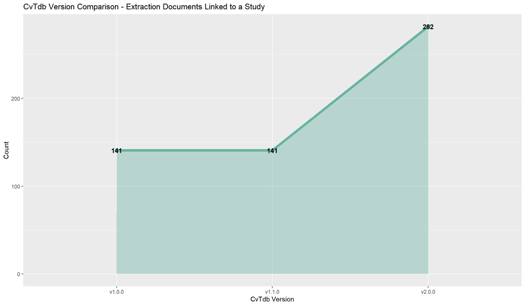

**Reference Documents Linked to a Study**

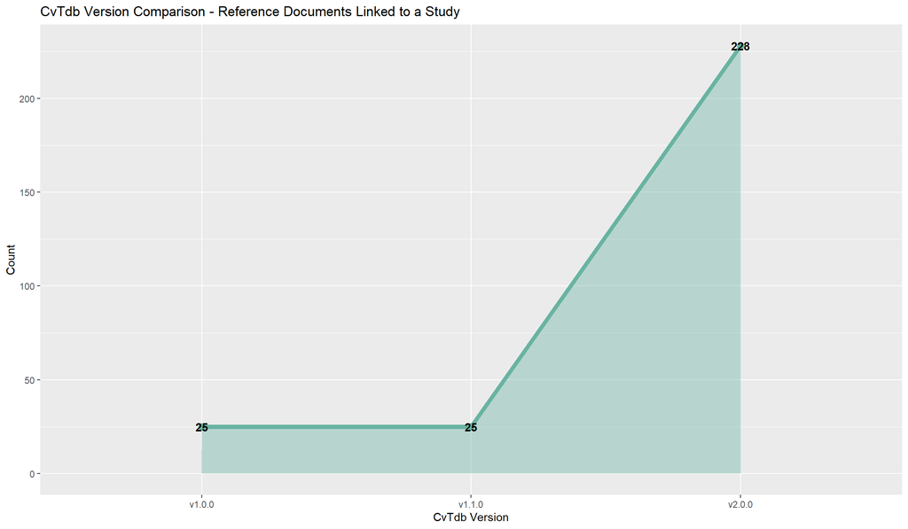

**Total Analyzed Chemicals Mapped to DTXSID**

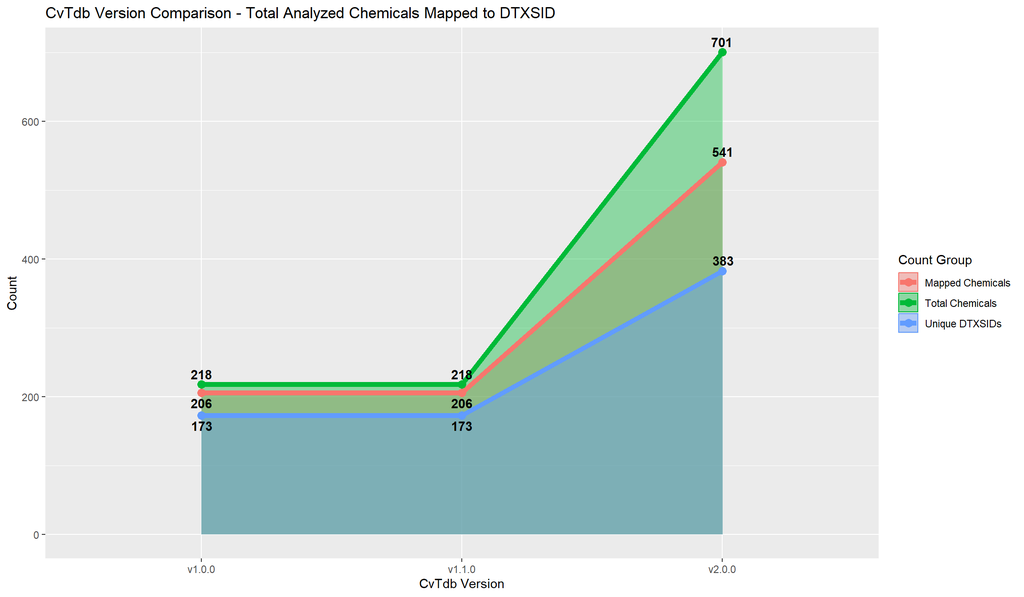

**Total Concentration Time Values with Normalized Units**

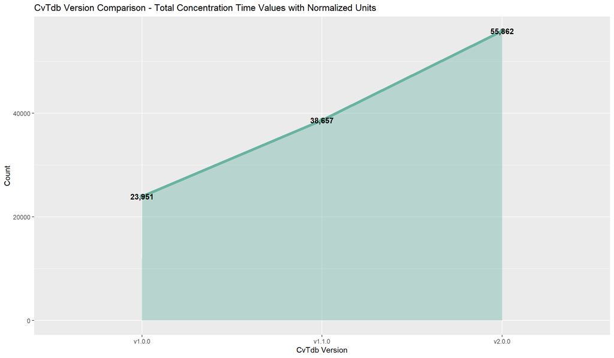

**Total Dosed Chemicals Mapped to DTXSID**

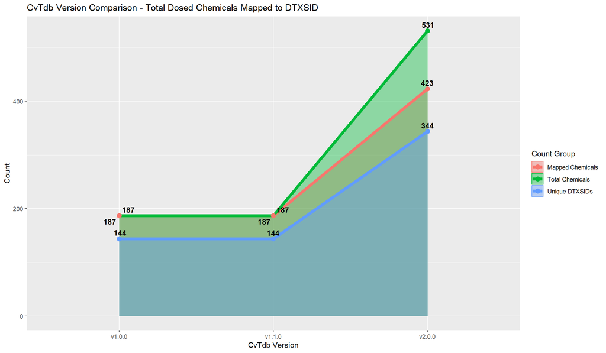

**Total Instances Where the Dosed Chemical is Different from the Analyzed Chemical**

| version | DTXSID Pairs | Studies | Series |
| --- | --- | --- | --- |
| v1.0.0 | 62 | 147 | 3070 |
| v1.1.0 | 62 | 145 | 3070 |
| v2.0.0 | 114 | 370 | 8110 |

**Total Series Linked to Conc_Time_Values**

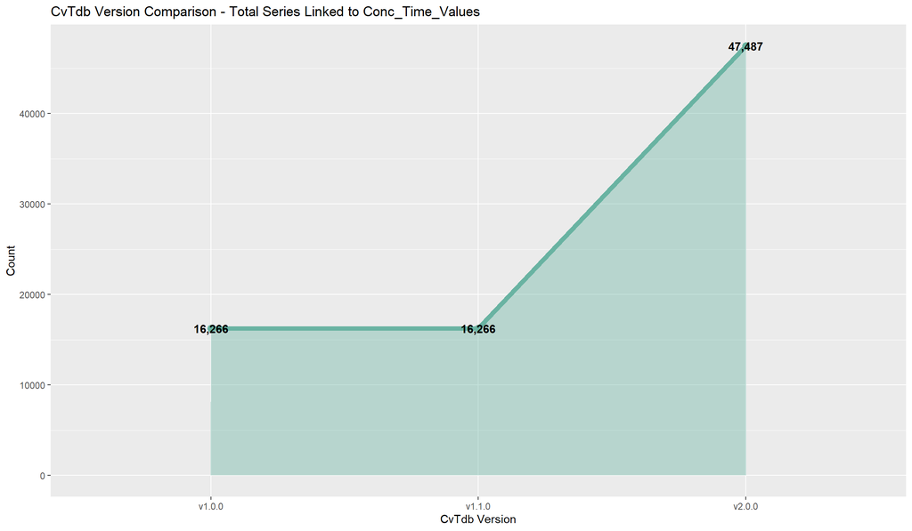

**Total Studies Linked to Series**

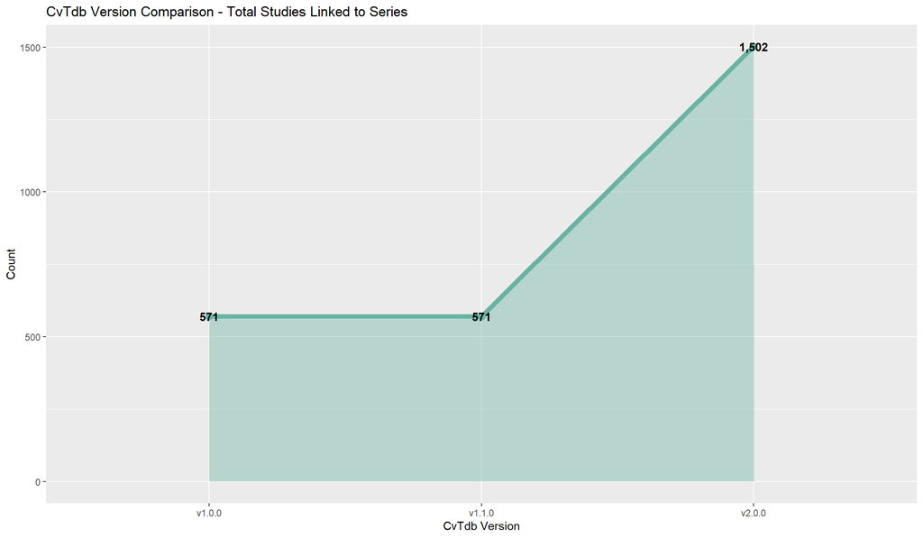

**Total Study Count by Administration Routes Linked to Series**

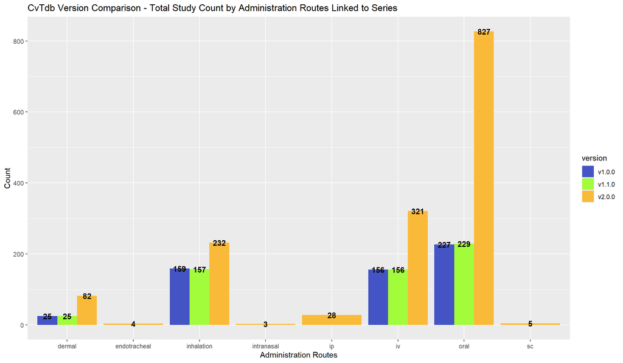

**Total Study Count by Species**

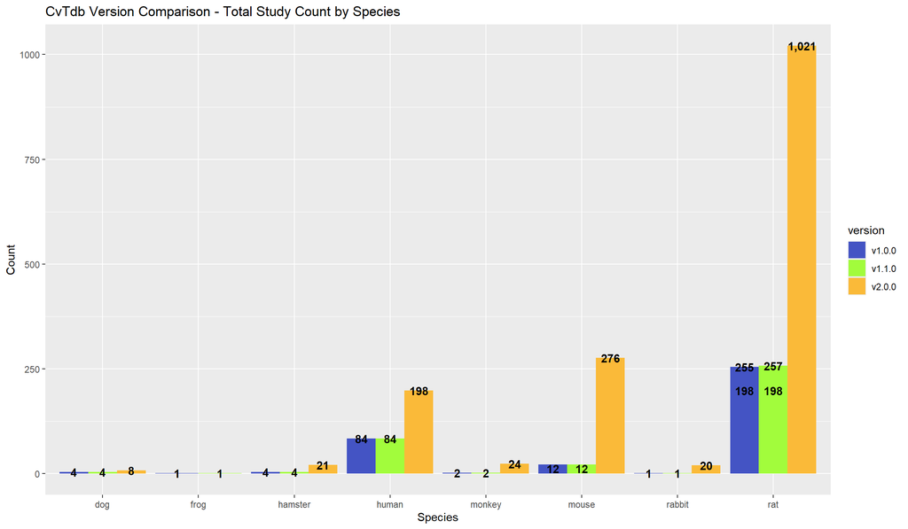

**Total Subjects**

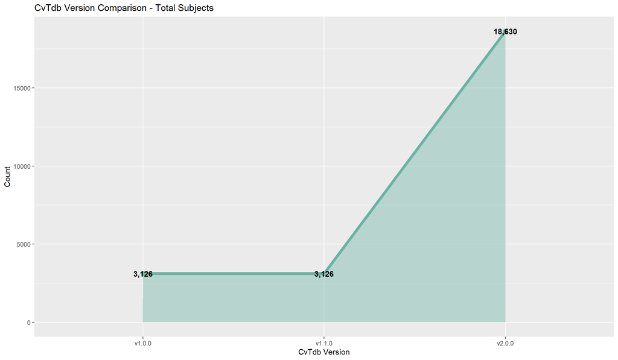

**Unique Chemical DTXSID Entries Linked to Study or Series**

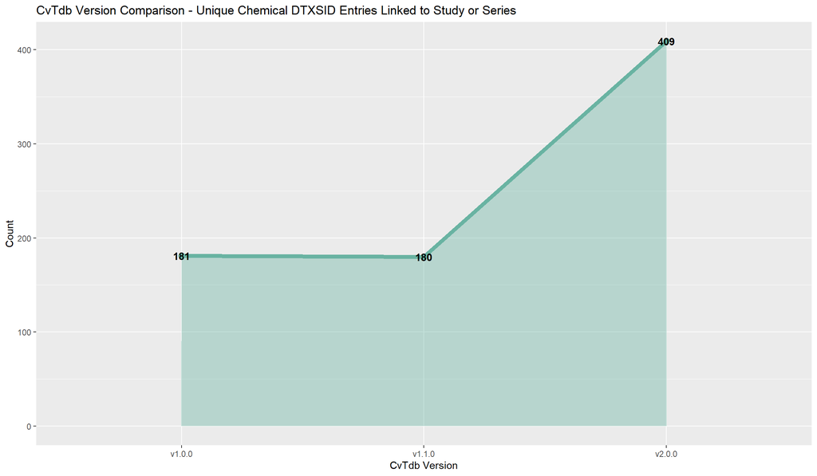

1. Total subjects changed dramatically between v1.1.0 and v2.0.0 due to an effort to shift towards creating unique Subject table entries per extraction document, rather than having documents share the same subject entry. This helped untangle and prevent cases where a document is QC’d and subject information is updated, causing subject information to be incorrect for other linked documents. This also helped support packages like *invivopkfit*, where curve fitting could treat each subject’s timecourse as unique. Also, NTP documents were re-extracted to report on a per-subject basis, often having hundreds of entries.
2. There are chemical table entries not currently linked to a Study or Series record. This is due to QC efforts that may have remapped these foreign keys. The entries were maintained in the chemicals table since they may be linked in the future if a study or series record reports the same original chemical identifiers.
3. Some documents report “control” studies, which do not have Series table linkages but were extracted for completeness. So, only the unique count of studies linked to series was reported here.
4. Dosed and analyzed chemical table entries represent unique chemical identifiers reported in a document. Different chemical table entries may be mapped to the same DTXSID value.
5. There are cases where a Series record is not linked to the Conc_Time_Values table because it only had tk_parameters table data. There are also Series records that do not have Conc_Time_Values table linkages that most likely need to be re-extracted or removed due to process changes.

Table 2: Summary of Administration Route and Species Counts by Dosed Chemical

| Dosed Chemical DTXSID | oral | iv | inhalation | dermal | rat | hamster | mouse | human | monkey | dog | rabbit |
| --- | --- | --- | --- | --- | --- | --- | --- | --- | --- | --- | --- |
| DTXSID00148077 | 1 | 0 | 0 | 0 | 1 | 0 | 0 | 0 | 0 | 0 | 0 |
| DTXSID00200321 | 1 | 0 | 0 | 0 | 1 | 0 | 0 | 0 | 0 | 0 | 0 |
| DTXSID0020232 | 1 | 0 | 0 | 0 | 1 | 0 | 0 | 0 | 0 | 0 | 0 |
| DTXSID0020365 | 0 | 4 | 0 | 0 | 4 | 0 | 0 | 0 | 0 | 0 | 0 |
| DTXSID0020442 | 11 | 6 | 0 | 0 | 9 | 4 | 4 | 0 | 0 | 0 | 0 |
| DTXSID0020652 | 3 | 1 | 0 | 0 | 4 | 0 | 0 | 0 | 0 | 0 | 0 |
| DTXSID0020868 | 6 | 2 | 2 | 0 | 3 | 0 | 5 | 2 | 0 | 0 | 0 |
| DTXSID0020941 | 4 | 2 | 0 | 0 | 3 | 0 | 3 | 0 | 0 | 0 | 0 |
| DTXSID0021123 | 0 | 1 | 0 | 0 | 1 | 0 | 0 | 0 | 0 | 0 | 0 |
| DTXSID0021125 | 0 | 1 | 0 | 0 | 1 | 0 | 0 | 0 | 0 | 0 | 0 |

[output cut: 328 more lines]

1. Note, counts are by unique studies, where a single study may have dosed through an administration route to multiple subject species. Therefore, by DTXSID, the sum of administration route counts may not equal the sum of species counts.

## 4 New Datasets

- Showa dataset (~200 reference documents)
  - Showa Pharmaceutical University/EPA Material Transfer Agreement, as described in Kamiya et al. 2020.
- CEBS NTP documents (New and Updated) (> 50)
  - The Chemical Effects in Biological Systems (CEBS) database is a comprehensive, publicly available database hosted by the National Toxicology Program (NTP). The data sourced from CEBS is primarily focused on oral gavage and intravenous routes of administration to rats and mice. This also included QC updates and re-extraction of documents, including remapping NTP study identifiers for document metadata (e.g., C55301B -> K55301B). All re-extractions started with a scripted autoextraction of the NTP XLSX raw data files into a CvTdb template, which was then reviewed by a curator for completeness.
- PK Working Group identified documents (> 55)
  - The PK Working Group (PKWG) as part of the US Environmental Protection Agency’s Integrated Risk Information System (IRIS) toxicokinetic assessments. These data contain toxicity values for chronic exposures and identifies and characterizes the health hazards of environmentally relevant chemicals. Chemicals included were PCBs, PFOS, PFOA, and PFAS.
- 3M documents (31)
  - 3M documents that were obtained via legal action with the Department of Justice. This set contains over 9,000 documents, 6,546 of which are currently being analyzed. The documents focus on PFAS monitoring and testing and are very heterogeneous.
- Dermal (18) and Inhalation (14) study documents
  - Expanded dermal and inhalation route study metadata data model.
  - Documents as referenced in Thompson et al. 2021.
  - Curated dermal data used in Meade et al. 2023 SOT poster.
  - Upcoming publication from Celia Schacht
- Inhalation study documents (14)
- TK Parameter documents (16)
  - Curation of 43 documents with TK parameters reported, 16 with CvTdb relevant studies, series, and concentration time values. Note, these were included in the release although they did not complete the standard QC review due to time and resource constraints.

## 5 New Features

- Updated standard operating procedures for data curation and QC.
- New fields added to study and subject fields to improve capture of study and subject attributes
  - ex. Subject health_status captures key differences in physiology across subjects that may impact measurable time-series data
- New/updated dermal and inhalation study metadata model.
  - Described in Rowan and Huse (2024) NC SOT Poster.
- Streamlined data processing workflow.
- Standardized QC workflow and programmatic approaches to flag records for review.
  - QC of over 60 documents based on queries to identify erroneous or incomplete study records. Re-extraction of over 80 documents to improve record representation with updated data model.
- New document_lineage table to improve reporting of relationships between documents (e.g., Supplemental Document, Study Methods Document, Reference Document)

## 6 Future Planned Features

- New data sources
  - Pharmacokinetics Database (PK-DB)
    - The Pharmacokinetics Database (PK-DB) is an open database containing pharmacokinetic data alongside metadata required for computation modeling and data integration. The data is sourced from clinical trials and pre-clinical research.
  - Toxicokinetic Knowledgebase (TKKB) documents
    - The list of citations for the TKKB set was meant to increase diversity of available CvT data and provide a means to compare bespoke toxicokinetic models with HTTK models. This dataset contained numerous studies with occupationally relevant routes of exposure (inhalation and dermal) that had not previously been loaded into CvTdb.
  - Mixture Data
    - Expansion of the CvTdb data model to handle studies with dosed chemical mixtures (in collaboration with Celia Schacht).

## 7 Known Issues

- Subjects table entries ID 46,283 and 53,441 have weight values of “25.D9” and “29 .4”, which were maintained as-is to reflect the true original value reported by the extraction document.
- The administration method, administration form, and conc_medium dictionaries have entries that are not normalized at this time. This was due to internal decisions related to interpretability and consistency of the use of authoritative vocabulary/ontology.
- Select dose and concentration units were not normalized due to their complexity, lack of required metadata, or potentially being out of scope for CvTdb. A QC effort is underway to review such records and determine if they can be fixed or should be removed.
  - Dose
    - percentage, concentration (mg/mL, ug/L), radioactive (uCi/kg), rates (mg/kg/day), surface area (mmol/m3), gas/liquid (nl gas/g, ul liquid/kg)
  - Concentration
    - percentage, radioactive (dpm/ml), rates (pmol/min), weights (nmol)

## 8 References

- Kamiya, Y., Otsuka, S., Miura, T., Yoshizawa, M., Nakano, A., Iwasaki, M., Kobayashi, Y., Shimizu, M., Kitajima, M., Shono, F., Funatsu, K., and Yamazaki, H. (2020). Physiologically Based Pharmacokinetic Models Predicting Renal and Hepatic Concentrations of Industrial Chemicals after Virtual Oral Doses in Rats. Chemical Research in Toxicology 33 (7), 1736-1751 DOI: 10.1021/acs.chemrestox.0c00009.
- Linakis, M. W., Sayre, R. R., Pearce, R. G., Sfeir, M. A., Sipes, N. S., Pangburn, H. A., Gearhart, J. M., & Wambaugh, J. F. (2020). Development and evaluation of a high throughput inhalation model for organic chemicals. Journal of exposure science & environmental epidemiology, 30(5), 866–877. https://doi.org/10.1038/s41370-020-0238-y.
- Meade., A., Wambaugh, J. F., Evans, M. V. (2023). Development and analysis of high throughput physiologically based pharmacokinetic/toxicokinetic (PBPK/TK) dermal exposure model. The United States Environmental Protection Agency’s Center for Computational Toxicology and Exposure. Poster. https://doi.org/10.23645/epacomptox.22637536.v1.
- Padilla Mercado, G., Cook, C., Adkins, N. et al. (2025). Informatics for toxicokinetics. J Pharmacokinet Pharmacodyn 52, 30. https://doi.org/10.1007/s10928-025-09977-4.
- Pearce, R. G., Setzer, R. W., Strope, C. L., Sipes, N. S., Wambaugh, J. F. (2017). httk: R Package for High-Throughput Toxicokinetics. Journal of Statistical Software, 79(4), 1–25. doi:10.18637/jss.v079.i04.
- Rowan, E. G., Huse, L., Aboabdo, J., Casey, W., Correa, V., Kesic, B. et al. (2024). Methods to Expand and Improve CvTdb: A Publicly Available Resource of Toxicokinetic Data. North Carolina Society of Toxicology 2024 Conference. Poster. https://doi.org/10.23645/epacomptox.28314863.v1.
- Sayre, R. R., Wambaugh, J. F. & Grulke, C. M. (2020). Database of pharmacokinetic time-series data and parameters for 144 environmental chemicals. Sci Data 7(122). https://doi.org/10.1038/s41597-020-0455-1.
- Thompson, C. V., Firman, J. W., Goldsmith, M. R., et al. (2021). A Systematic Review of Published Physiologically-based Kinetic Models and an Assessment of their Chemical Space Coverage. Alternatives to Laboratory Animals. 49(5):197-208. doi:10.1177/02611929211060264.
- U.S. EPA. Recommendations For And Documentation Of Biological Values For Use In Risk Assessment. U.S. Environmental Protection Agency, Washington, DC, EPA/600/6-87/008 (NTIS PB88179874), 1988.
- Wambaugh, J. F., Wetmore, B. A., Pearce, R., Strope, C., Goldsmith, R., Sluka, J. P., Sedykh, A., Tropsha, A., Bosgra, S., Shah, I., Judson, R., Thomas, R. S., Setzer, R. W. (2015). Toxicokinetic Triage for Environmental Chemicals. Toxicol Sci. 147(1):55-67. doi: 10.1093/toxsci/kfv118.
- Wambaugh, J., Ring, C., Padilla Mercado, G., Cook, C. (2025). invivoPKfit: Fits Toxicokinetic Models to In Vivo PK Data Sets. R package version 2.0.1, https://CRAN.R-project.org/package=invivoPKfit.

## 9 Contributors

CvTdb has required a huge undertaking from several teams, and we have a lot of contributors to thank for their role in improving the robustness and quality of the database.

Special thanks to team members who contributed to CvTdb as a data curator: Michael F. Hughes, Lucas Albrecht, Grace Cary, Brenda Edwards, Nancy M. Hanley, Anna Jarnagin, Tirumala D. Kodavanti, Evgenia Korol-Bexell, Anna Kreutz, Mayla Ngo, Caitlyn Patullo, Hiroshi Yamazaki, Evelyn G. Rowan, L. McKenna Huse, Veronica A. Correa, Branislav Kesic, Robert “Will” Casey, Jennat Aboabdo, Kaitlyn Wolf, Jasmine Hope.

Additional thanks to Evelyn G. Rowan and L. McKenna Huse for scoping and implementing the data model expansion to include dermal and inhalation studies.

Additional thanks to John Wambaugh and Gilberto Padilla Mercado for their feedback throughout this curation cycle as end-users developing the httk and invivopkfit packages.

## 10 Database Field Definitions

### 10.1 administration_form_dict

Table 3: administration_form_dict

| column_name | short_description | examples | notes |
| --- | --- | --- | --- |
| administration_form_normalized | The vessel of delivery or state of test_substance. |  | As of v2.0.0, this field was not filled in. |
| administration_form_original | Original value reported in the extraction document. See corresponding "_normalized" field or field without "_original" stem. | capsule, vapor, paste |  |
| concept_identifier | Unique identifier assigned to a concept within the domain of mammalian experimentation as designated in the concept_identifier_dictionary. |  | As of v2.0.0, this field was not filled in. |
| concept_identifier_dictionary | Name of an authoritative vocabulary, dictionary, or ontology which defines concepts within the domain of mammalian experimentation. |  | As of v2.0.0, this field was not filled in. |
| concept_identifier_dictionary_description | Label or name used by the concept_identifier_dictionary to describe the concept_identifier. |  | As of v2.0.0, this field was not filled in. |
| created_by | Name of user who created the record. |  |  |
| id | Autogenerated unique numeric table identifier. |  |  |
| rec_create_dt | Datetime for when record was created. |  |  |

### 10.2 administration_method_dict

Table 4: administration_method_dict

| column_name | short_description | examples | notes |
| --- | --- | --- | --- |
| administration_method_normalized | The specific manner that the test substance is given via the administration_route. |  | As of v2.0.0, this field was not filled in. |
| administration_method_original | Original value reported in the extraction document. See corresponding "_normalized" field or field without "_original" stem. | gavage, infusion, nose-only, immersion |  |
| concept_identifier | Unique identifier assigned to a concept within the domain of mammalian experimentation as designated in the concept_identifier_dictionary. |  | As of v2.0.0, this field was not filled in. |
| concept_identifier_dictionary | Name of an authoritative vocabulary, dictionary, or ontology which defines concepts within the domain of mammalian experimentation. |  | As of v2.0.0, this field was not filled in. |
| concept_identifier_dictionary_description | Label or name used by the concept_identifier_dictionary to describe the concept_identifier. |  | As of v2.0.0, this field was not filled in. |
| created_by | Name of user who created the record. |  |  |
| id | Autogenerated unique numeric table identifier. |  |  |
| rec_create_dt | Datetime for when record was created. |  |  |

### 10.3 administration_route_dict

Table 5: administration_route_dict

| column_name | short_description | examples | notes |
| --- | --- | --- | --- |
| administration_route_normalized | How the test substance was administered to the subject. | oral, iv, inhalation, dermal |  |
| administration_route_original | Original value reported in the extraction document. See corresponding "_normalized" field or field without "_original" stem. | subcutaneous, intravenous, intratracheal |  |
| concept_identifier | Unique identifier assigned to a concept within the domain of mammalian experimentation as designated in the concept_identifier_dictionary. | C0205535, C1522583 |  |
| concept_identifier_dictionary | Name of an authoritative vocabulary, dictionary, or ontology which defines concepts within the domain of mammalian experimentation. | UMLS |  |
| concept_identifier_dictionary_description | Label or name used by the concept_identifier_dictionary to describe the concept_identifier. | Inhalation Route of Administration, Intraperitoneal Route of Administration |  |
| created_by | Name of user who created the record. |  |  |
| id | Autogenerated unique numeric table identifier. |  |  |
| rec_create_dt | Datetime for when record was created. |  |  |

### 10.4 chemicals

Table 6: chemicals

| column_name | short_description | examples | notes |
| --- | --- | --- | --- |
| casrn_original | Original value reported in the extraction document. See corresponding "_normalized" field or field without "_original" stem. | 30516-87-1 |  |
| chemical_name_original | Original value reported in the extraction document. See corresponding "_normalized" field or field without "_original" stem. | Rifampicin |  |
| chemical_name_secondary_original | Original value reported in the extraction document. See corresponding "_normalized" field or field without "_original" stem. | 3'-Azido-3'-deoxythymidine |  |
| chemistry_team_mapping | Whether the DTXSID listed came from standard chemical curation team or was provided in the document. | NA (not curated to DTXSID), 0 (No), 1 (Yes) | Primarily was used for datasets provided to CvTdb team, like the Showa dataset. |
| created_by | Name of user who created the record. |  |  |
| curation_notes | Chemical curation team curation flags/notes about the DTXSID mapping. | CAS-RN matched cleaned_casrn; Preferred Name matched cleaned_name |  |
| dsstox_casrn | Chemical Abstracts Registry Number. | 30516-87-1 |  |
| dsstox_substance_id | DSSTox generic susbtance ID. | DTXSID8020127 |  |
| id | Autogenerated unique numeric table identifier. |  |  |
| preferred_name | DSSTox preferred chemical name. | 3'-Azido-3'-deoxythymidine |  |

[output cut: 1 more lines]

### 10.5 conc_medium_dict

Table 7: conc_medium_dict

| column_name | short_description | examples | notes |
| --- | --- | --- | --- |
| conc_medium_normalized | Medium of the sample from which the concentration describes. | plasma, urine, liver |  |
| conc_medium_original | Original value reported in the extraction document. See corresponding "_normalized" field or field without "_original" stem. | kidney, exhaled alveolar, adipose tissue |  |
| concept_identifier | Unique identifier assigned to a concept within the domain of mammalian experimentation as designated in the concept_identifier_dictionary. | C0005767 |  |
| concept_identifier_dictionary | Name of an authoritative vocabulary, dictionary, or ontology which defines concepts within the domain of mammalian experimentation. | UMLS |  |
| concept_identifier_dictionary_description | Label or name used by the concept_identifier_dictionary to describe the concept_identifier. | Blood |  |
| created_by | Name of user who created the record. |  |  |
| has_httk_compartment_mapping | Flag of whether the conc_medium_original has an httk compartment mapping. If not, then normalized field is purposefully left blank. | NA (not determined), 0 (No), 1 (Yes) |  |
| id | Autogenerated unique numeric table identifier. |  |  |
| rec_create_dt | Datetime for when record was created. |  |  |
| units | N/A. | ug/ml, ug/m3 | Field not used at this time. |

### 10.6 conc_time_values

Table 8: conc_time_values

| column_name | short_description | examples | notes |
| --- | --- | --- | --- |
| conc | Numeric or non-numeric concentration value reported in associated series. |  | ND: not detected; NQ: not quantified; NA: missing; NE: not extractable; NR: not reported. |
| conc_bound_type | Free text, the type of boundary reported. | standard error, confidence interval, standard deviation |  |
| conc_lower_bound | Numeric OR non-numeric option (free text options as specified in conc description), the lower bound interval value for the concentration data point. |  |  |
| conc_lower_bound_original | Original value reported in the extraction document. See corresponding "_normalized" field or field without "_original" stem. |  |  |
| conc_original | Original value reported in the extraction document. See corresponding "_normalized" field or field without "_original" stem. |  |  |
| conc_sd | Numeric OR non-numeric option (free text options as specified in conc description), the standard deviation of the concentration data point. |  |  |
| conc_sd_original | Original value reported in the extraction document. See corresponding "_normalized" field or field without "_original" stem. |  |  |
| conc_upper_bound | Numeric OR non-numeric option (free text options as specified in conc description), the upper bound interval value for the concentration data point. |  |  |
| conc_upper_bound_original | Original value reported in the extraction document. See corresponding "_normalized" field or field without "_original" stem. |  |  |
| created_by | Name of user who created the record. |  |  |

[output cut: 11 more lines]

### 10.7 cvt_audit

Table 9: cvt_audit

| column_name | short_description | examples | notes |
| --- | --- | --- | --- |
| created_by | Name of user who created the record. |  |  |
| fk_table_id | Foreign key identifier for associated fk_table_name table entry. | 2683 |  |
| fk_table_name | Name of table the audit record came from. | documents |  |
| id | Autogenerated unique numeric table identifier. |  |  |
| qc_flags | Flags added to record during QC. | conc_conversion_needed_percentage |  |
| qc_notes | Notes added to record during QC. | Add conc_bound_type, conc_upper_bound, conc_lower_bound; reextracted conc/time while extracting the conc bounds |  |
| qc_status | Status of QC for the record, always set to "FAIL" since it was audited. | FAIL |  |
| rec_create_dt | Datetime for when record was created. |  |  |
| rec_end_dt | Datetime for when record was moved to audit table. |  |  |
| record | JSON of the corresponding audited record in field-value pairs. | {"pmid" : "2507310", "doi" : null, "first_author" : null, "year" : null, "title" : null, "other_study_identifier" : null, "url" : null, "extracted" : "0", "tentatively_identified_test_substance" : "['… |  |

[output cut: 1 more lines]

### 10.8 documents

Table 10: documents

| column_name | short_description | examples | notes |
| --- | --- | --- | --- |
| clowder_file_id | Clowder file identifier for the document record. | 65832c83e4b063812d5a786c | Used to navigate to the particular Clowder file URL /files/{id}. |
| clowder_template_id | Clowder file identifier for the template used to extract the record. | 65c514b1e4b063812d6944d9 | Used to navigate to the particular Clowder file URL /files/{id}. |
| created_by | Name of user who created the record. |  |  |
| curation_set_tag | Dataset tag from Jira curation ticket labels. | inhalation, CVT_Legacy, PCB | CVT_Legacy is a tag for v1.0.0 documents. Note, tags can be overwritten due to QC and re-extraction. See the cvt_audit table logs for a document. |
| curator_comment | Free text, comments provided by the curator during their extraction process. | Series removed for QC due to conc_medium_original |  |
| doi | Digital Object Identifier for document. | 10.1016/0272-0590(90)90205-x |  |
| effects_data | Boolean, indicates whether the document contains effects data (e.g. biological response to dosed chemical, such as tumor incidence counts). | 0 (No); 1 (Yes) |  |
| extracted | Flags describing a document’s status of data extraction. Field can include multiple flags (semi-colon or comma separated). |  | 0: Document has been flagged for potential CvTdb relevant data; 1: Document’s CvT data (that is currently supported) has been completely extracted; 2: Retired flag (initially meaning “incomplete extra… |
| fifra | Flag for if document contained data relevant to FIFA. | 1 | Deprecated as of v1.1.0. |
| first_author | Name of first author for document. | Yeung PK |  |

[output cut: 21 more lines]

### 10.9 documents_lineage

Table 11: documents_lineage

| column_name | short_description | examples | notes |
| --- | --- | --- | --- |
| created_by | Name of user who created the record. |  |  |
| fk_doc_id | Foreign key identifier for associated documents table entry. |  |  |
| fk_parent_doc_id | Foreign key identifier for associated documents table entry that is the parent in the document relationship. |  |  |
| id | Autogenerated unique numeric table identifier. |  |  |
| rec_create_dt | Datetime for when record was created. |  |  |
| relationship_type | Tag describing the relationship between the linked documents. | Supplemental Document, Study Methods Document, Reference Document |  |

### 10.10 dose_frequency_dict

Table 12: dose_frequency_dict

| column_name | short_description | examples | notes |
| --- | --- | --- | --- |
| concept_identifier | Unique identifier assigned to a concept within the domain of mammalian experimentation as designated in the concept_identifier_dictionary. | C1948045 |  |
| concept_identifier_dictionary | Name of an authoritative vocabulary, dictionary, or ontology which defines concepts within the domain of mammalian experimentation. | UMLS |  |
| concept_identifier_dictionary_description | Label or name used by the concept_identifier_dictionary to describe the concept_identifier. | Once (schedule frequency) |  |
| created_by | Name of user who created the record. |  |  |
| dose_frequency_normalized | Number of exposures a subject encounters per unit of time. | single dose, 1/day, 5/week |  |
| dose_frequency_original | Original value reported in the extraction document. See corresponding "_normalized" field or field without "_original" stem. | Once, 1/day, 5/week |  |
| id | Autogenerated unique numeric table identifier. |  |  |
| rec_create_dt | Datetime for when record was created. |  |  |

### 10.11 series

Table 13: series

| column_name | short_description | examples | notes |
| --- | --- | --- | --- |
| analyte_casrn_original | Original value reported in the extraction document. See corresponding chemicals table entry using fk_analyzed_chemical_id field. | 67-56-1 |  |
| analyte_name_original | Original value reported in the extraction document. See corresponding chemicals table entry using fk_analyzed_chemical_id field. | 3-hydroxybenzo(a)pyrene |  |
| analyte_name_secondary_original | Original value reported in the extraction document. See corresponding chemicals table entry using fk_analyzed_chemical_id field. | 3-OHBaP |  |
| analytical_method_detail | Reported details for the analytical method. | GC/MS |  |
| author_comment | Free text, details about the study provided by the author(s) in the document. | 1 subject of 6; 23 yo, 74 kg; below LOQ at all time points |  |
| conc_cumulative | Boolean, indicates if concentrations are cumulative (if concentrations increase over time and represent an accumulation of current and previous values). | 0 (No); 1 (Yes) |  |
| conc_medium_original | Original value reported in the extraction document. See corresponding "_normalized" field or field without "_original" stem. | expired breath |  |
| conc_units_normalized | Reported concentration units converted to ug/ml. | ug/ml, ugEq/ml |  |
| conc_units_original | Original value reported in the extraction document. See corresponding "_normalized" field or field without "_original" stem. | ug/mL, umol |  |
| created_by | Name of user who created the record. |  |  |

[output cut: 27 more lines]

### 10.12 studies

Table 14: studies

| column_name | short_description | examples | notes |
| --- | --- | --- | --- |
| administration_form_original | Original value reported in the extraction document. See corresponding administration_form_dict entry using fk_administration_form_id field. | vapor |  |
| administration_method_original | Original value reported in the extraction document. See corresponding administration_method_dict entry using fk_administration_method_id field. | whole-body |  |
| administration_route_original | Original value reported in the extraction document. See corresponding administration_route_dict entry using fk_administration_route_id field. | inhalation |  |
| administration_term | Numeric, elapsed time (from first to final dose) over which multiple doses are administered. | 120 |  |
| administration_term_units | Units of measure for administration term. | minutes |  |
| aerosol_particle_density | Numeric, value of the reported particle density of test substance. |  |  |
| aerosol_particle_density_units | Units for aerosol_particle_density. |  |  |
| aerosol_particle_diameter_gsd | Numeric, reported particle diameter standard deviation value. |  |  |
| aerosol_particle_diameter_mean | Numeric, reported particle diameter mean value. |  |  |
| aerosol_particle_diameter_units | Units for reported particle diameter units. |  |  |

[output cut: 46 more lines]

### 10.13 subjects

Table 15: subjects

| column_name | short_description | examples | notes |
| --- | --- | --- | --- |
| age | Reported age of subject. | 20-36 |  |
| age_category | Age category of the subject. | adult, infant |  |
| age_units | Reported age units of subject. | years |  |
| created_by | Name of user who created the record. |  |  |
| curator_comment | Free text, comments provided by the curator during their extraction process. | inhalation, sampled @ t = 30min |  |
| health_status | details describing physical differences (not chemically induced) between subjects (e.g. "pregnant", "bile duct cannulated", "neutered", “lactating”, “ovariectomized”, “50W bike” (applied physical work… | coarctation of aorta, common ventrical; ; critically ill |  |
| height | Reported height of subject. | 162-185 |  |
| height_cm | Reported height of subject in centimeters. | 173.5 |  |
| height_units | Reported height units of subject. | cm |  |
| id | Autogenerated unique numeric table identifier. |  |  |

[output cut: 12 more lines]

### 10.14 tk_parameters

Table 16: tk_parameters

| column_name | short_description | examples | notes |
| --- | --- | --- | --- |
| calculated_with_invivopkfit | Boolean for whether parameter was calculated using invivopkfit. If not, parameter came from another source or document. | 0 (No); 1 (Yes) |  |
| calculation_date | Date when calculation was performed. |  |  |
| comment | Free text, comments provided about tk_parameter generation. | calculated in Python 3.5 with numpy 1.13.3 trapz |  |
| created_by | Name of user who created the record. |  |  |
| fk_chemical_id | Foreign key identifier for associated chemicals table entry. |  |  |
| fk_series_id | Foreign key identifier for associated series table entry. |  |  |
| fk_study_id | Foreign key identifier for associated studies table entry. |  |  |
| id | Autogenerated unique numeric table identifier. |  |  |
| invivopkfit_version | Version ofinvivopkfit used for tk parameter calculations. |  |  |
| omit_from_ccd | Boolean for whether to not display the parameter record on the CompTox Chemicals Dashboard. | 0 (No); 1 (Yes) |  |

[output cut: 12 more lines]

### 10.15 tk_parameters_series

Table 17: tk_parameters_series

| column_name | short_description | examples | notes |
| --- | --- | --- | --- |
| created_by | Name of user who created the record. |  | Table in development. |
| fk_series_id | Foreign key identifier for associated series table entry. |  | Table in development. |
| fk_tk_parameters_id | Foreign key identifier for associated tk_parameters table entry. |  | Table in development. |
| id | Autogenerated unique numeric table identifier. |  | Table in development. |
| rec_create_dt | Datetime for when record was created. |  | Table in development. |
| version | Record version number. |  | Table in development. |

### 10.16 tk_parameters_studies

Table 18: tk_parameters_studies

| column_name | short_description | examples | notes |
| --- | --- | --- | --- |
| created_by | Name of user who created the record. |  | Table in development. |
| fk_studies_id | Foreign key identifier for associated studies table entry. |  | Table in development. |
| fk_tk_parameters_id | Foreign key identifier for associated tk_parameters table entry. |  | Table in development. |
| id | Autogenerated unique numeric table identifier. |  | Table in development. |
| rec_create_dt | Datetime for when record was created. |  | Table in development. |
| version | Record version number. |  | Table in development. |